# QQ-plots on ancestry-based GWAS

Andrey Ziyatdinov

2017-04-04

# 1 First QQ-plots v0

Traits under study: FEV1pp_utah, FEV1_utah, FVCpp_utah, FVC_utah, FEV1_FVC_utah, log_pctEmph_Slicer, TLCpp_race_adjusted, finalGold_bin.

The following QQ-plots are produced for all traits under the model v0.

| trait | ver | formula |
| --- | --- | --- |
| FEV1pp_utah | 0 | FEV1pp_utah ~ Age_Enroll + gender + SmokCigNow + ATS_PackYears + acs_global |
| FEV1_utah | 0 | FEV1_utah ~ Age_Enroll + Age_Enroll2 + gender + Height_CM + SmokCigNow + ATS_PackYears + acs_global |
| FVCpp_utah | 0 | FVCpp_utah ~ Age_Enroll + gender + SmokCigNow + ATS_PackYears + acs_global |
| FVC_utah | 0 | FVC_utah ~ Age_Enroll + Age_Enroll2 + gender + Height_CM + SmokCigNow + ATS_PackYears + acs_global |
| FEV1_FVC_utah | 0 | FEV1_FVC_utah ~ Age_Enroll + Age_Enroll2 + gender + SmokCigNow + ATS_PackYears + acs_global |
| log_pctEmph_Slicer | 0 | log_pctEmph_Slicer ~ Age_Enroll + gender + SmokCigNow + ATS_PackYears + acs_global |
| TLCpp_race_adjusted | 0 | TLCpp_race_adjusted ~ Age_Enroll + gender + SmokCigNow + ATS_PackYears + acs_global |
| finalGold_bin | 0 | finalGold_bin ~ Age_Enroll + gender + SmokCigNow + ATS_PackYears + acs_global |

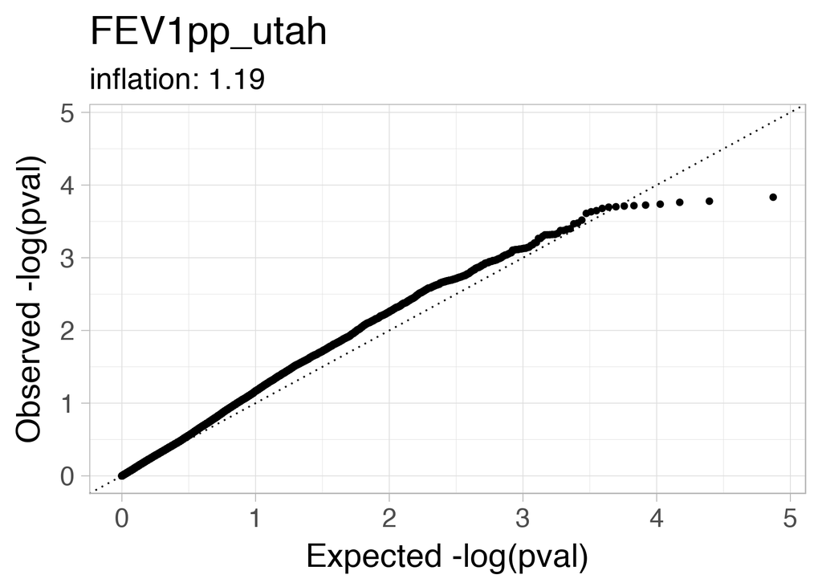

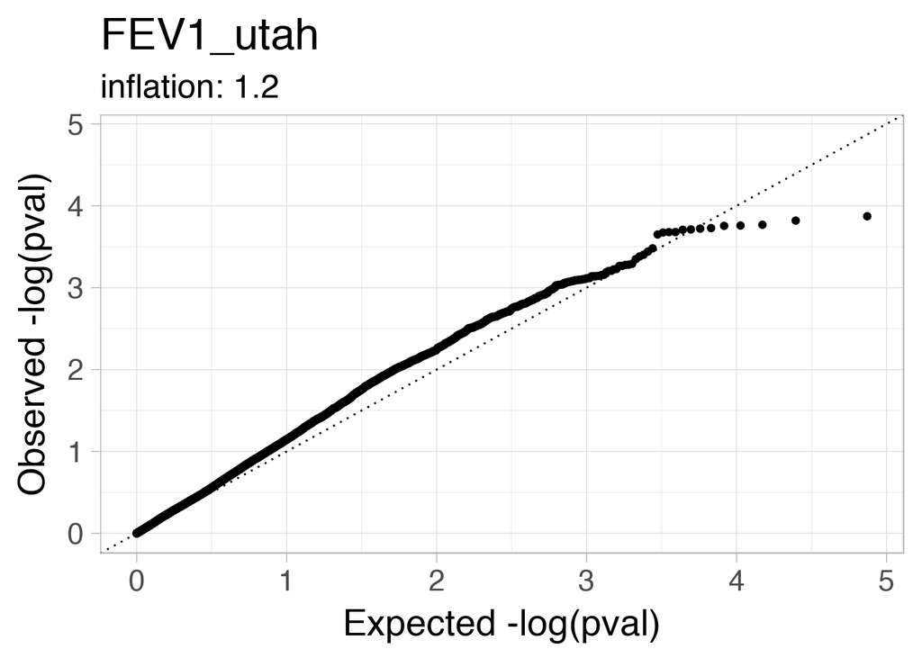

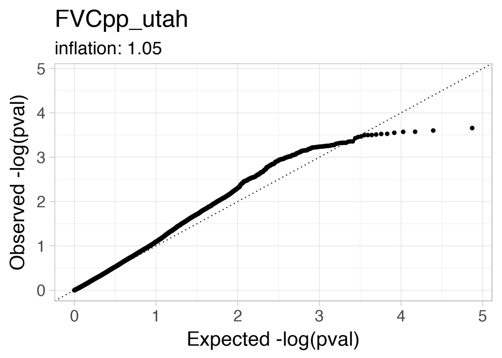

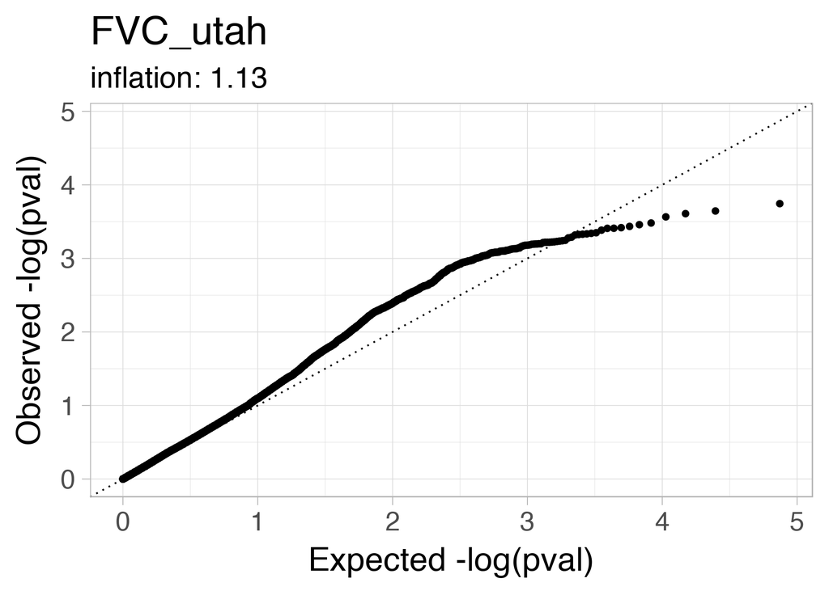

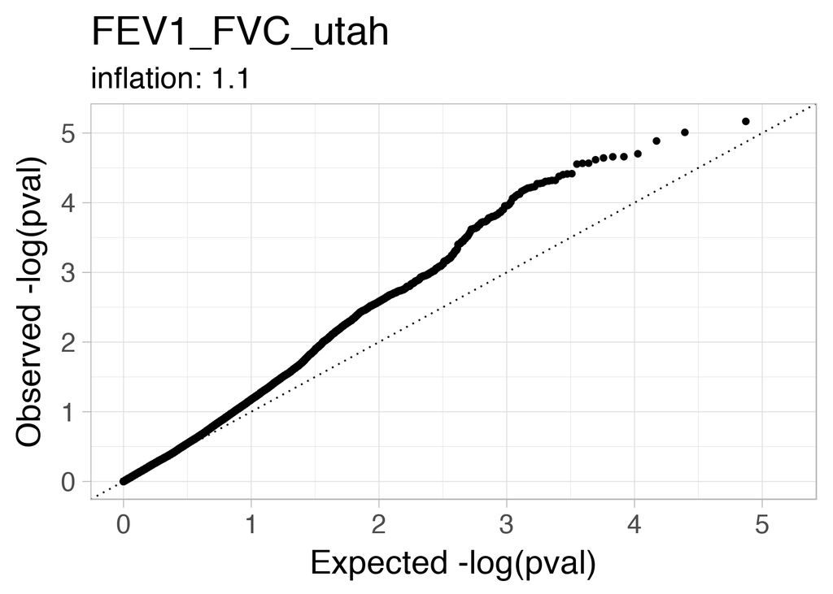

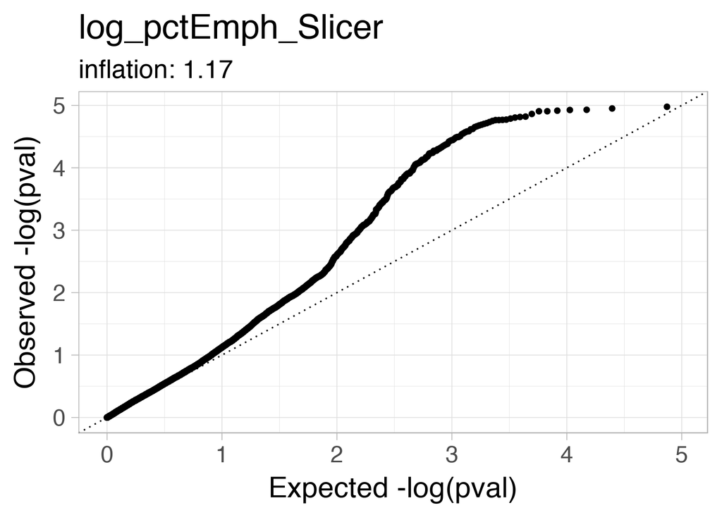

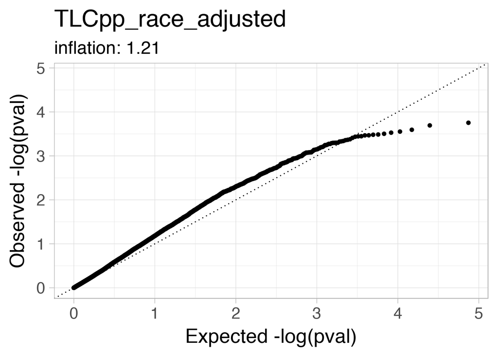

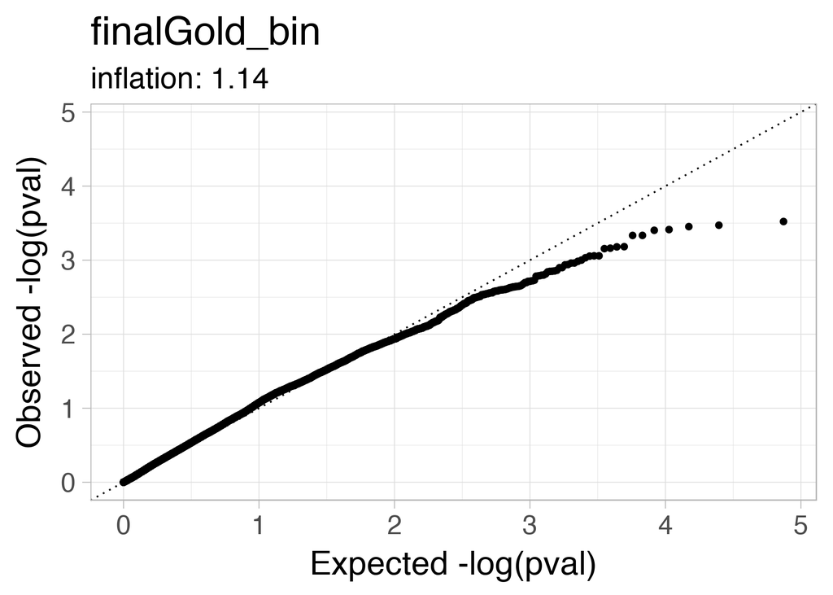

# 2 QQ-plots v0-5 + tunnings

The QQ-plots for a single trait FEV1pp_utah are shown.

The description of the model versions:

| trait | ver | formula |
| --- | --- | --- |
| FEV1pp_utah | 0 | FEV1pp_utah ~ Age_Enroll + gender + SmokCigNow + ATS_PackYears + acs_global |
| FEV1pp_utah | 1 | FEV1pp_utah ~ Age_Enroll + gender + SmokCigNow + ATS_PackYears + acs_global + (1\|ccenter) |
| FEV1pp_utah | 2 | FEV1pp_utah ~ Age_Enroll + gender + SmokCigNow + ATS_PackYears + acs_global + pc1 + pc2 + pc3 + pc4 |
| FEV1pp_utah | 3 | FEV1pp_utah ~ Age_Enroll + gender + SmokCigNow + ATS_PackYears + acs_global + pc1 + pc2 + pc3 + pc4 + (1\|ccenter) |
| FEV1pp_utah | 4 | FEV1pp_utah ~ Age_Enroll + gender + SmokCigNow + ATS_PackYears + acs_global + apc1 + apc2 + apc3 + apc4 |
| FEV1pp_utah | 5 | FEV1pp_utah ~ Age_Enroll + gender + SmokCigNow + ATS_PackYears + acs_global + apc1 + apc2 + apc3 + apc4 + (1\|ccenter) |

First, we tried different versions 0, 1, 2, 4.

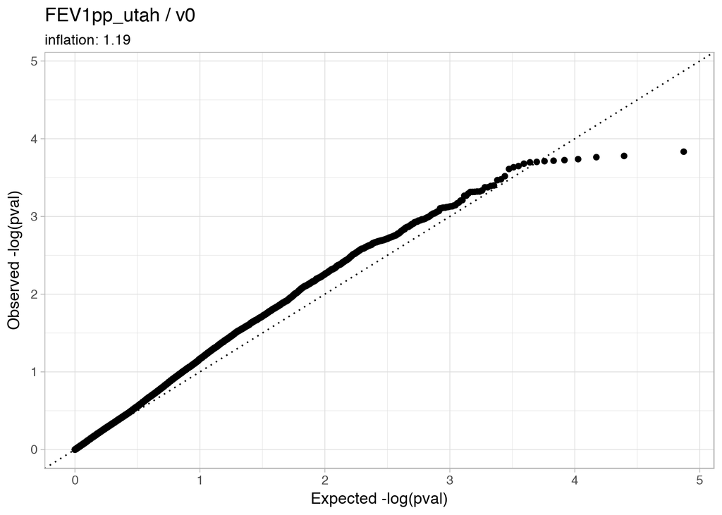

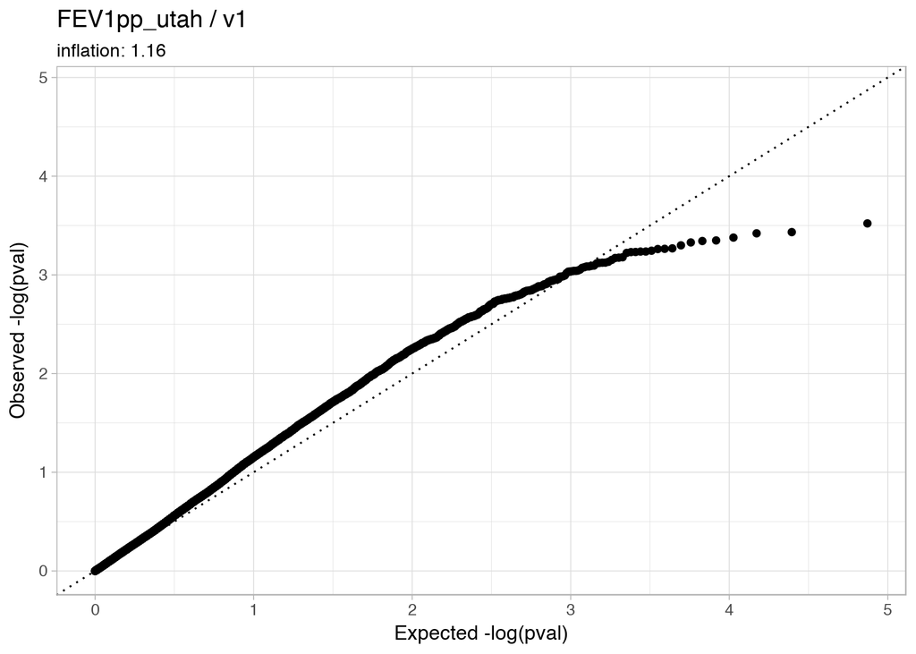

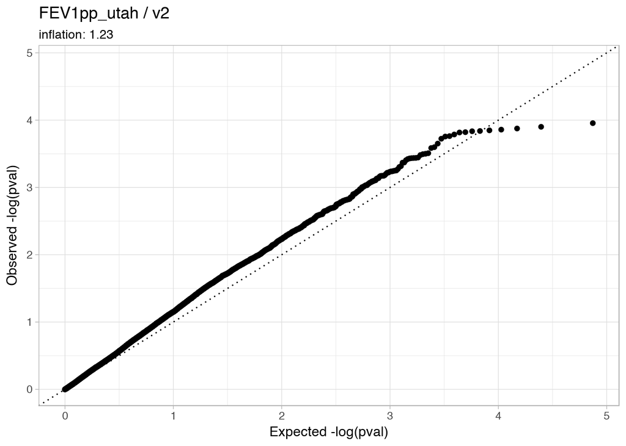

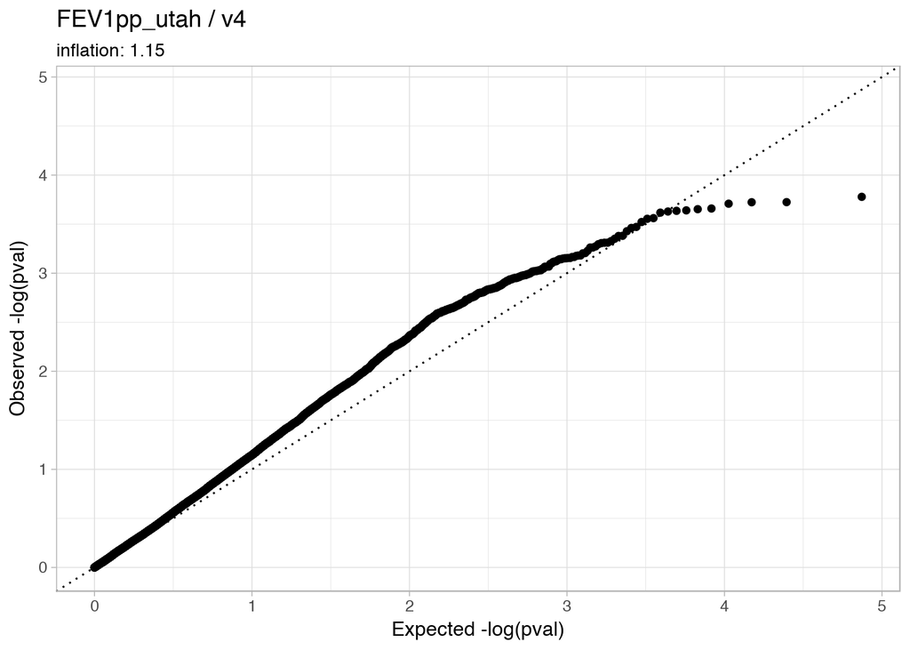

Second, we applied a few additional tunnings:

- use LRT instead of the Wald test;
- filter out unrelated individuals (kinship > 0.025);
  - Among 3,300 African-Americans, there are no pairs with kinship > 0.125
  - The threshold 0.025 was used as in http://biorxiv.org/content/early/2016/05/01/036640
  - The number of related individuals (kinship > 0.025) was 117 out of 3,300

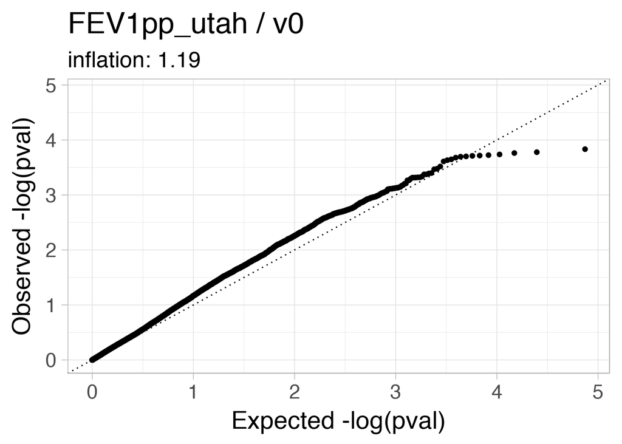

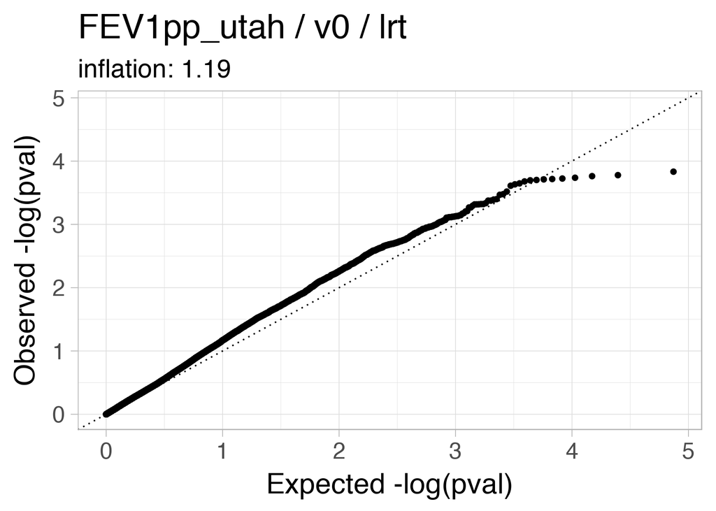

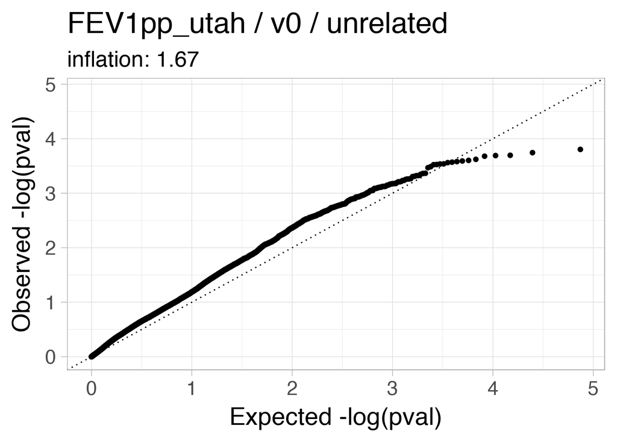

# 3 Scan on interactions with `SmokCigNow`

Once we fix the inflation in marginal scans, we can switch to the interaction QQ-plots. Now, it is inflated a lot.

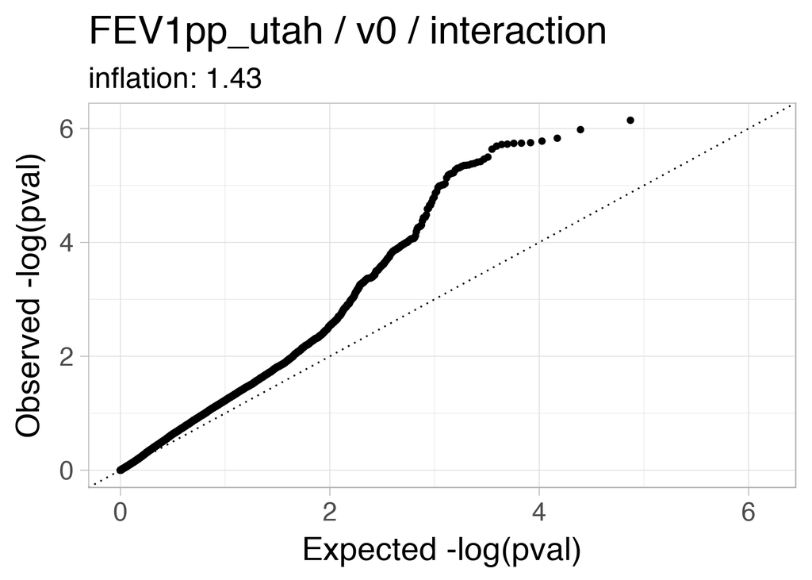

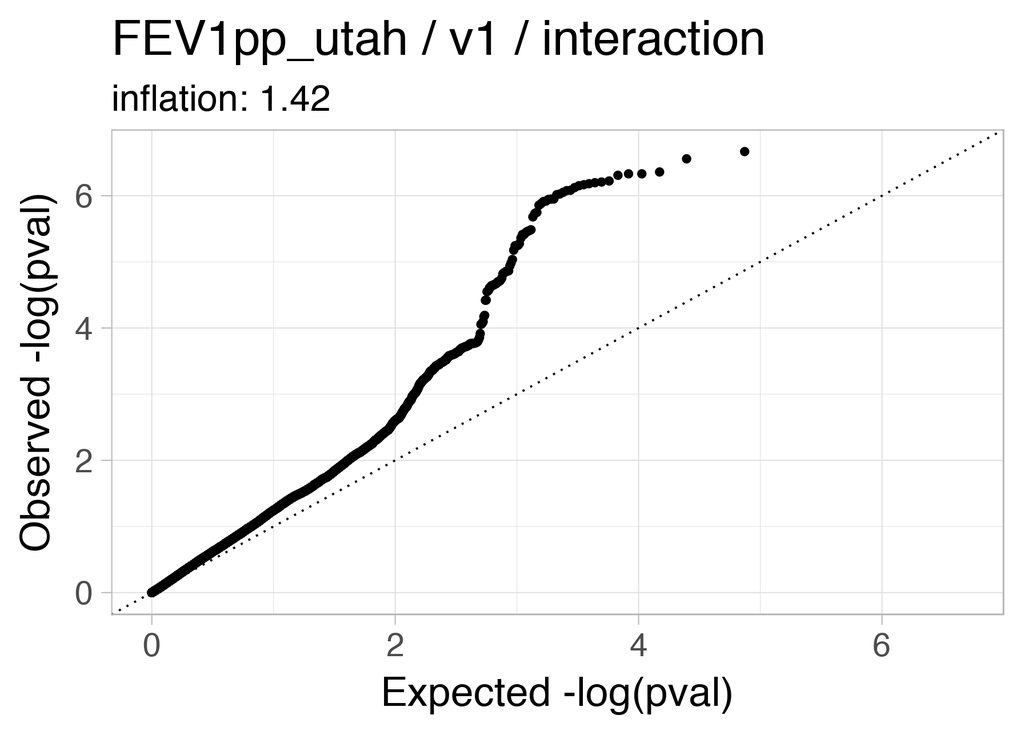

# 4 Principal components

- PCs on genotypes received from Michael.
- Ancestry PCs were computed on long ancestry segments
- Global ancestry esimated as average across all local ancestries
  - Generally, it is not the same as global ancestry estimated by specialized programs

The relationships among PC1, Ancestry PC1 and global ancestry:

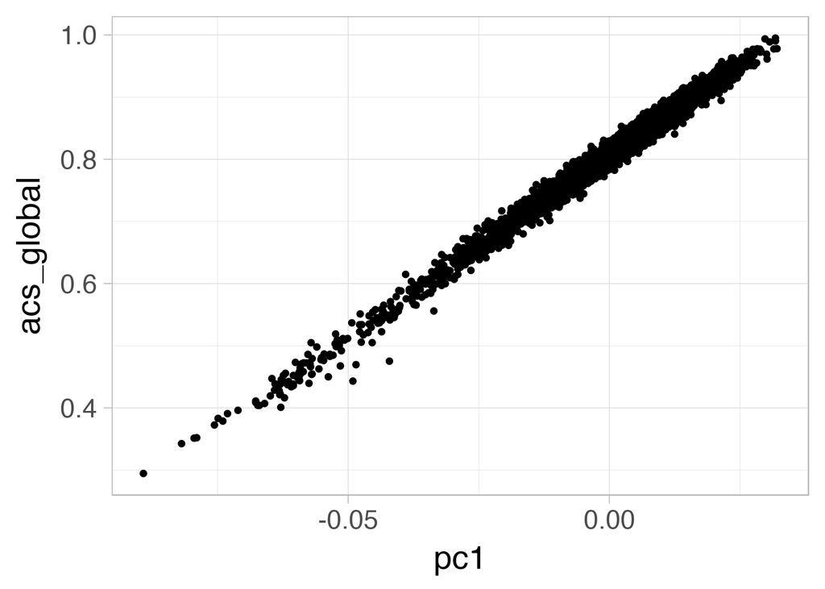

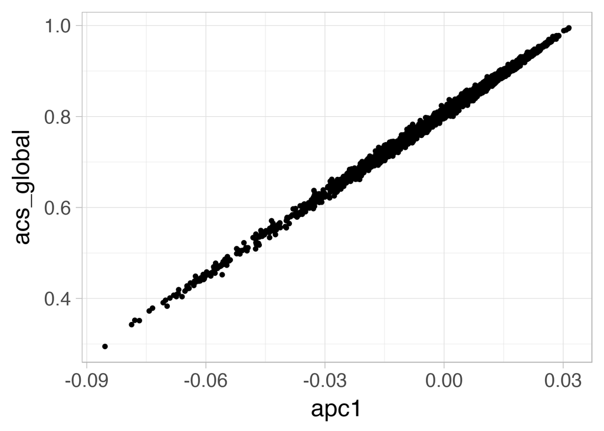

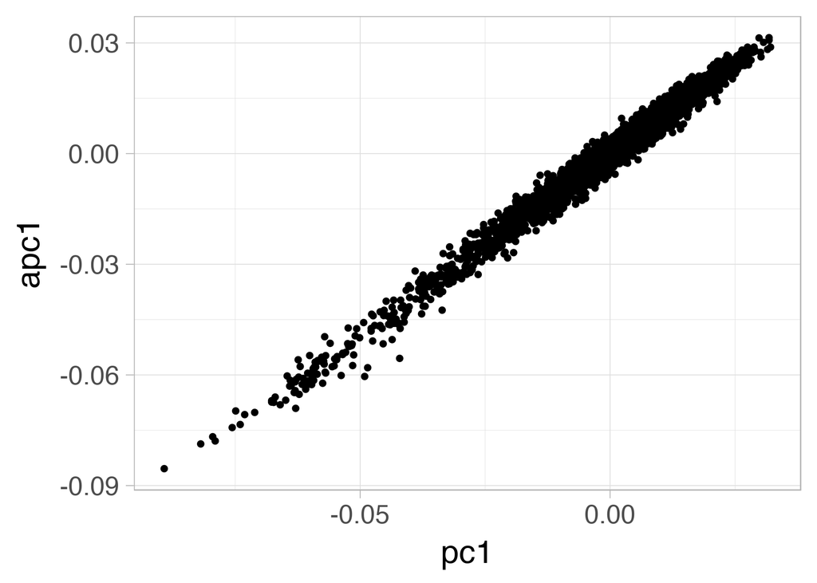

## 4.1 Ancestry principal components

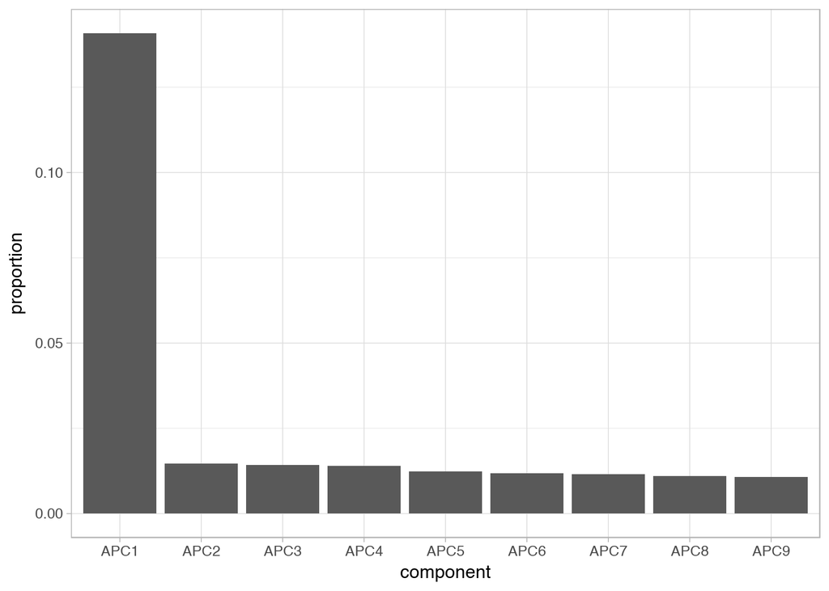

The second ancestry PC explains only a variance proportion equal to 0.015.